# Predicting Telco Customer Churn

## By Christian Parlade

#### Blog post can be found at link below:

#### https://cparlade.github.io/PredictingChurn/

Are you a business owner or manager looking to reduce customer churn and retain your valuable customers? Predictive analytics can help you identify customers who are at risk of churning and take proactive measures to keep them satisfied. In this blog post, we will explore how to use the Telco Customer Churn dataset to predict customer churn using various machine learning techniques. We will start by understanding the dataset and its features and then move on to data preprocessing and feature engineering. Finally, we will train and evaluate several machine learning models and choose the best one for predicting customer churn. By the end of this blog post, you will have a good understanding of how to predict customer churn and use this information to improve customer retention in your business.

The problem of customer churn is a critical concern for businesses, especially those in the highly competitive telecommunications industry. Churn occurs when customers stop using a company's products or services, and it can have a significant impact on revenue and growth. Predicting customer churn has become increasingly important as companies look to retain their customers and reduce the costs associated with acquiring new ones.

## Initial Exploratory Data Analysis of the Categorical Variables

Let's begin by loading the data, taking a closer look at what the data is like, and creating some visualizations to help us wrap our heads around what is in the data we are working with.

```python
import csv
import pandas as pd
import platform
import time
import json
import os
import numpy as np
from sklearn.model_selection import train_test_split
from sklearn.linear_model import Perceptron, LogisticRegression
from sklearn.svm import SVC
from sklearn.metrics import accuracy_score, precision_score, recall_score, f1_score
from sklearn.preprocessing import LabelEncoder
from sklearn.preprocessing import StandardScaler, MinMaxScaler
from io import StringIO
import matplotlib.pyplot as plt
import seaborn as sns
```

```python
os.chdir('C:/Users/e19439/Downloads/')
path = os.getcwd()

print(path)
```

```
C:\Users\e19439\Downloads
```

```python
data = pd.read_csv('churn_data.csv')
# checking columns and data types to ensure the columns have the correct type
data.info()
```

```
<class 'pandas.core.frame.DataFrame'>
RangeIndex: 7043 entries, 0 to 7042
Data columns (total 21 columns):
 #   Column            Non-Null Count  Dtype
---  ------            --------------  -----
 0   customerID        7043 non-null   object
 1   gender            7043 non-null   object
 2   SeniorCitizen     7043 non-null   int64
 3   Partner           7043 non-null   object
 4   Dependents        7043 non-null   object
 5   tenure            7043 non-null   int64
 6   PhoneService      7043 non-null   object
 7   MultipleLines     7043 non-null   object
 8   InternetService   7043 non-null   object
 9   OnlineSecurity    7043 non-null   object
 10  OnlineBackup      7043 non-null   object
 11  DeviceProtection  7043 non-null   object
 12  TechSupport       7043 non-null   object
 13  StreamingTV       7043 non-null   object
 14  StreamingMovies   7043 non-null   object
 15  Contract          7043 non-null   object
 16  PaperlessBilling  7043 non-null   object
 17  PaymentMethod     7043 non-null   object
 18  MonthlyCharges    7043 non-null   float64
 19  TotalCharges      7043 non-null   object
 20  Churn             7043 non-null   object
dtypes: float64(1), int64(2), object(18)
memory usage: 1.1+ MB
```

```python
# converting wrong columns, in this case TotalCharges to numeric
data['TotalCharges'] = pd.to_numeric(data['TotalCharges'], errors='coerce')
```

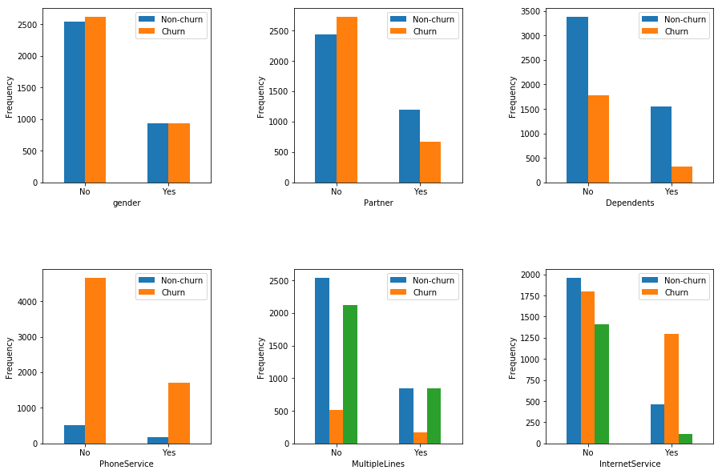

```python
# plotting the distributions of the categorical variables by churn vs non-churn

fig, axs = plt.subplots(2, 3, figsize=(15, 10))
fig.subplots_adjust(hspace = 0.5, wspace=0.5)
axs = axs.ravel()

cat_vars = ['gender', 'Partner', 'Dependents', 'PhoneService', 'MultipleLines', 'InternetService']
for i, var in enumerate(cat_vars):
    data.groupby(['Churn', var])[var].count().unstack().plot(kind='bar', ax=axs[i], rot=0)
    axs[i].set_xlabel(var)
    axs[i].set_ylabel('Frequency')
    axs[i].legend(['Non-churn', 'Churn'])

plt.show()
```

#### EDA Recap

In the code snippets above, we are using the popular data science and machine learning libraries in Python to perform exploratory data analysis (EDA) on the telco customer churn dataset we introduced earlier. First, we read in the dataset using the Pandas library and checked the data types of the columns to ensure they have the correct types. We also converted any incorrect data types using the pd.to_numeric() function.

Next, we plotted the distributions of the categorical variables by churn vs non-churn using the Matplotlib library. We grouped the data by the Churn variable and each of the categorical variables (gender, Partner, Dependents, PhoneService, MultipleLines, InternetService) and plotted them as bar charts.

The EDA stage is a critical step in any machine learning project. It helps to identify patterns, trends, and relationships in the data, which can inform feature engineering, model selection, and hyperparameter tuning

#### EDA Cont.

```python
# Check for missing values
data.isnull().sum()
```

```
customerID           0
gender               0
SeniorCitizen        0
Partner              0
Dependents           0
tenure               0
PhoneService         0
MultipleLines        0
InternetService      0
OnlineSecurity       0
OnlineBackup         0
DeviceProtection     0
TechSupport          0
StreamingTV          0
StreamingMovies      0
Contract             0
PaperlessBilling     0
PaymentMethod        0
MonthlyCharges       0
TotalCharges        11
Churn                0
dtype: int64
```

```python
# dropping missing values and removing customerID
data.dropna(inplace = True)
data = data.iloc[:,1:]
# Converting categorical variables to numerical variables
data['gender'] = pd.factorize(data['gender'])[0]
data['Partner'] = pd.factorize(data['Partner'])[0]
data['Dependents'] = pd.factorize(data['Dependents'])[0]
data['PhoneService'] = pd.factorize(data['PhoneService'])[0]
data['MultipleLines'] = pd.factorize(data['MultipleLines'])[0]
data['InternetService'] = pd.factorize(data['InternetService'])[0]
data['OnlineSecurity'] = pd.factorize(data['OnlineSecurity'])[0]
data['OnlineBackup'] = pd.factorize(data['OnlineBackup'])[0]
data['DeviceProtection'] = pd.factorize(data['DeviceProtection'])[0]
data['TechSupport'] = pd.factorize(data['TechSupport'])[0]
data['StreamingTV'] = pd.factorize(data['StreamingTV'])[0]
data['StreamingMovies'] = pd.factorize(data['StreamingMovies'])[0]
data['Contract'] = pd.factorize(data['Contract'])[0]
data['PaperlessBilling'] = pd.factorize(data['PaperlessBilling'])[0]
data['PaymentMethod'] = pd.factorize(data['PaymentMethod'])[0]
data['Churn'] = pd.factorize(data['Churn'])[0]

data.isnull().sum()
```

```
gender              0
SeniorCitizen       0
Partner             0
Dependents          0
tenure              0
PhoneService        0
MultipleLines       0
InternetService     0
OnlineSecurity      0
OnlineBackup        0
DeviceProtection    0
TechSupport         0
StreamingTV         0
StreamingMovies     0
Contract            0
PaperlessBilling    0
PaymentMethod       0
MonthlyCharges      0
TotalCharges        0
Churn               0
dtype: int64
```

```python
# looking at our changes so far
data.head()
```

|  | gender | SeniorCitizen | Partner | Dependents | tenure | PhoneService | MultipleLines | InternetService | OnlineSecurity | OnlineBackup | DeviceProtection | TechSupport | StreamingTV | StreamingMovies | Contract | PaperlessBilling | PaymentMethod | MonthlyCharges | TotalCharges | Churn |
| --- | --- | --- | --- | --- | --- | --- | --- | --- | --- | --- | --- | --- | --- | --- | --- | --- | --- | --- | --- | --- |
| 0 | 0 | 0 | 0 | 0 | 1 | 0 | 0 | 0 | 0 | 0 | 0 | 0 | 0 | 0 | 0 | 0 | 0 | 29.85 | 29.85 | 0 |
| 1 | 1 | 0 | 1 | 0 | 34 | 1 | 1 | 0 | 1 | 1 | 1 | 0 | 0 | 0 | 1 | 1 | 1 | 56.95 | 1889.50 | 0 |
| 2 | 1 | 0 | 1 | 0 | 2 | 1 | 1 | 0 | 1 | 0 | 0 | 0 | 0 | 0 | 0 | 0 | 1 | 53.85 | 108.15 | 1 |
| 3 | 1 | 0 | 1 | 0 | 45 | 0 | 0 | 0 | 1 | 1 | 1 | 1 | 0 | 0 | 1 | 1 | 2 | 42.30 | 1840.75 | 0 |
| 4 | 0 | 0 | 1 | 0 | 2 | 1 | 1 | 1 | 0 | 1 | 0 | 0 | 0 | 0 | 0 | 0 | 0 | 70.70 | 151.65 | 1 |

After visualizing the data, we checked for missing values in our dataset using isnull().sum(). We found that the 'TotalCharges' column has missing values. Since we can't accurately fill in these values, we opted to drop the missing values altogether using dropna(inplace = True). Next, we removed the customerID column as it does not contribute to our analysis.

To prepare our categorical variables for the models, we used pd.factorize() to convert them to numerical variables. This allows our models to understand and use the categorical data as a predictor. After factorizing each variable, we checked once again for missing values using isnull().sum(). This time, we found no missing values. Finally, we looked at the first few rows of our cleaned and prepared dataset using data.head().

## EDA of the numerical variables and seeing how balanced the data is

```python
# seeing how balanced our data set is
print(data['Churn'].value_counts())
```

```
0    5163
1    1869
Name: Churn, dtype: int64
```

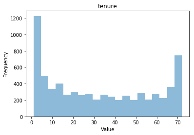

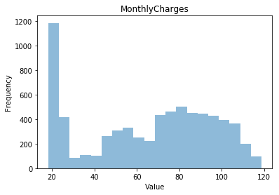

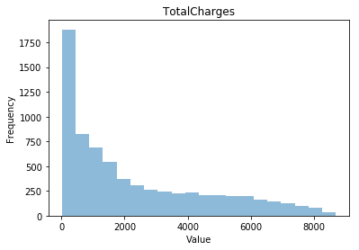

```python
# creating a list of numerical column names
num_cols = ['tenure', 'MonthlyCharges', 'TotalCharges']

# looping through each numerical column and create a histogram to see the distribution
for col in num_cols:
    plt.hist(data[col], bins=20, alpha=0.5)
    plt.title(col)
    plt.xlabel('Value')
    plt.ylabel('Frequency')
    plt.show()
```

#### EDA Recap

After cleaning our data by handling missing values and converting categorical variables to numerical variables, we now want to see how balanced our dataset is. We can do this by looking at the number of customers who churned and those who did not churn. We use the value_counts() method to count the number of occurrences of each unique value in the "Churn" column.

Next, we create a list of numerical column names in our dataset, namely 'tenure', 'MonthlyCharges', and 'TotalCharges'. We loop through each column in the list and create a histogram to visualize the distribution of each variable. We set the number of bins to 20 and set the transparency of the histogram bars to 0.5. This allows us to see the frequency distribution of each numerical column and to check if there are any outliers. The title of each histogram indicates which column it represents, and the x and y labels show the value and frequency respectively.

#### Graphing Correlation of the variables

Now, let's take a look at how our features correlate with churn. This will help us garner an idea of which variables have an impact on churn and give us an idea if we should do feature selection.

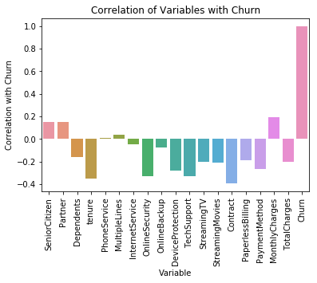

```python
# creating and plotting a correlation matrix
sns.barplot(x=corr['Churn'].index[1:], y=corr['Churn'][1:])
plt.title('Correlation of Variables with Churn')
plt.xlabel('Variable')
plt.ylabel('Correlation with Churn')
plt.xticks(rotation=90)
plt.show()
```

```python
# dropping low correlation variables
# data.drop(columns = ['PhoneService', 'MultipleLines', 'InternetService'],inplace = True)
```

```python
# Creating our X and Y datasets
X = data.drop(columns = ['Churn'])
y = data['Churn'].values
```

## Preprocessing our data

One interesting observation we made when we explored the distribution of our numerical features is that they do not follow a normal distribution. This is particularly important when it comes to feature scaling since some scaling methods assume that the data follows a normal distribution.

Here, we chose to use MinMaxScaler instead of StandardScaler because MinMaxScaler scales the data to a range between 0 and 1 and is robust to outliers, whereas StandardScaler scales the data to have a mean of 0 and a standard deviation of 1. However, StandardScaler can be sensitive to outliers and may not perform well on non-Gaussian distributions.

Since our data has a non-Gaussian distribution, using MinMaxScaler is a better choice as it preserves the range of the original data while ensuring that all the features are on the same scale, which is a requirement for many machine learning algorithms.

```python
# Split the data into training and testing sets

# Scale features
scaler = MinMaxScaler()
X_scaled = scaler.fit_transform(X)
X_train, X_test, y_train, y_test = train_test_split(X_scaled, y, test_size=0.3, random_state=42)
```

```python
from sklearn import metrics

# Modeling with logistic regression
model = LogisticRegression()
result = model.fit(X_train, y_train)

prediction_test = model.predict(X_test)
# finding model accuracy
print (metrics.accuracy_score(y_test, prediction_test))
```

```
0.7919431279620853
```

## Logistic Regression

After cleaning and preparing our dataset, we are now ready to build our predictive model. In this section of the code, we will be using several machine learning algorithms to predict customer churn. We will begin by splitting our data into training and testing sets, and then scale our features using the MinMaxScaler function from the sklearn library.

After splitting our data and scaling the features, we will use the logistic regression algorithm to train our model. Logistic regression is a binary classification algorithm that works well for predicting whether a customer will churn or not. We will fit the model to our training data and make predictions on our testing data. The accuracy score of the model on the testing data will be printed.

The result of running the logistic regression model is an accuracy score of 0.7919, which indicates that the model is able to accurately predict whether a customer will churn or not almost 80% of the time. However, this score may not be sufficient for some businesses, so we will also explore other machine learning algorithms to see if we can improve our results.

```
AxesSubplot(0.125,0.125;0.775x0.755)
gender             -0.023569
SeniorCitizen       0.284246
Partner            -0.143989
Dependents         -0.303262
tenure             -3.061982
OnlineSecurity     -0.906823
OnlineBackup        0.398652
DeviceProtection   -0.052156
TechSupport        -0.881293
StreamingTV         0.380005
StreamingMovies     0.395905
Contract           -1.622676
PaperlessBilling   -0.262446
PaymentMethod      -0.386189
MonthlyCharges      1.466253
TotalCharges        1.313619
dtype: float64
```

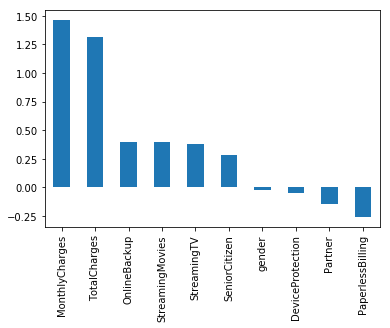

```python
# plotting variable weights
weights = pd.Series(model.coef_[0],
                 index=X.columns.values)
print (weights.sort_values(ascending = False)[:10].plot(kind='bar'))
print (weights)
```

```
AxesSubplot(0.125,0.125;0.775x0.755)
```

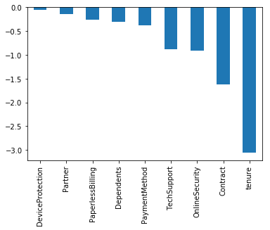

```python
print(weights.sort_values(ascending = False)[-9:].plot(kind='bar'))
```

The above code is used to plot the variable weights of the logistic regression model. Variable weights indicate the importance of each feature in predicting the target variable, which is churn in this case.

From the above weights, we can see that tenure, contract, and monthly charges are among the most significant features in predicting customer churn, while features such as gender, partner, and device protection have a lower impact on predicting customer churn.

For example, a higher tenure (i.e., longer period of subscription) will have a negative impact on the prediction of customer churn, as evidenced by the large negative weight (-3.061982). Conversely, higher monthly charges will have a positive impact on the prediction of customer churn, as evidenced by the large positive weight (1.466253).

```python
# Using random forest, experimented with test split size and hyperparamaters here
from sklearn.ensemble import RandomForestClassifier
X_train, X_test, y_train, y_test = train_test_split(X_scaled, y, test_size=0.25, random_state=42)
rf = RandomForestClassifier(n_estimators=1900 , #max_depth = 100,
                                  random_state =42, max_features = "sqrt",
                                  min_samples_split = 10)

rf.fit(X_train, y_train)
prediction_test = rf.predict(X_test)

accuracy = accuracy_score(y_test, prediction_test)
precision = precision_score(y_test, prediction_test)
recall = recall_score(y_test, prediction_test)
f1 = f1_score(y_test, prediction_test)
results = pd.DataFrame([[accuracy, precision, recall, f1]], columns=['Accuracy', 'Precision', 'Recall', 'F1 Score'])
print(results)
```

```
   Accuracy  Precision    Recall  F1 Score
0  0.790102   0.629738  0.471616  0.539326
```

After creating and evaluating a logistic regression model, we decided to experiment with a random forest classifier to see if we could improve our results. We split the data into training and testing sets using a test size of 0.25 and scaled the features using the MinMaxScaler.

We experimented with different hyperparameters and found the best combination that resulted in the highest accuracy, precision, recall, and F1 score. We set the number of estimators to 1900, max features to "sqrt", and minimum samples split to 10. We then fit the model to our training data and made predictions on our test data.

The results of the random forest classifier showed an accuracy of 0.790102, precision of 0.629738, recall of 0.471616, and an F1 score of 0.539326. These results indicate that the random forest classifier did not perform significantly better than the logistic regression model. However, it is worth noting that the performance of the random forest classifier can be improved by experimenting with different hyperparameters and tuning the model to fit the specific dataset.

```
gender              0.018484
SeniorCitizen       0.018836
Partner             0.016333
Dependents          0.015136
tenure              0.163199
OnlineSecurity      0.069812
OnlineBackup        0.021462
DeviceProtection    0.021298
TechSupport         0.056933
StreamingTV         0.020169
StreamingMovies     0.020820
Contract            0.126612
PaperlessBilling    0.019635
PaymentMethod       0.058768
MonthlyCharges      0.180809
TotalCharges        0.171695
dtype: float64
```

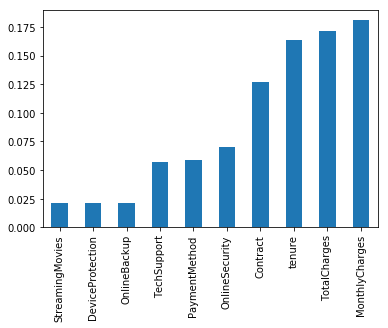

```python
# Get the feature importances from the random forest regressor
importances = rf.feature_importances_


# Print the feature ranking
weights = pd.Series(importances,index=X.columns.values)
weights.sort_values()[-10:].plot(kind = 'bar')

print(weights)
```

## Results and Comparisons

After training the random forest classifier with various hyperparameters, we obtained an accuracy of 0.790102, precision of 0.629738, recall of 0.471616, and F1 score of 0.539326. In an attempt to understand the importance of each feature in our model, we plotted the feature importances as shown above.

When comparing the importances of the features between the two models, we can see that they are quite different. For example, in the logistic regression model, the feature with the largest weight was tenure. Other features that had a strong association with customer churn in the logistic regression model included OnlineSecurity, TechSupport, and Contract.

In contrast, the feature with the highest importance in the random forest model was MonthlyCharges, with an importance score of 0.180809. This indicates that customers who pay higher monthly charges are more likely to churn. Other features that were important in the random forest model included TotalCharges, tenure, and Contract.

It is worth noting that the weights and importances of the features can vary between models and can be influenced by a range of factors, such as the size and quality of the data, the type of model used, and the hyperparameters chosen. Therefore, it is important to carefully consider the results of each model and interpret them in the context of the specific problem being addressed.

### Challenges and obstacles faced

I faced a few challenges in this project. The first challenge was running into an issue and error when looking for missing values. At first, I missed that the TotalCharges column was labelled incorrectly and thus had to go back to find why I actually missing values.

The final challenge I faced was using Github pages itself. I have rarely used Github nor have I written a blog post. Getting the Github set up, the website functioning correctly, and iterating several attempts to get the webpage to appear decent, was an exercise in patience and discipline.

## Conclusion

In conclusion, we have explored two different models for predicting customer churn in a telecommunications company and compared the weights and importances of the features between them. While the results of the two models differ, they both provide valuable insights into the factors that are most strongly associated with customer churn.